# Exercici Arbres de Decisió ML 2023

David Galera

```python
from google.colab import drive
drive.mount('/content/drive')
```

```python
import pandas as pd
from xgboost import XGBClassifier, plot_importance
import xgboost as xgb
from sklearn import metrics
from sklearn.model_selection import cross_val_score, GridSearchCV, KFold, RandomizedSearchCV, train_test_split
from time import time
import numpy as np
from sklearn.preprocessing import StandardScaler
from sklearn.metrics import auc, accuracy_score, confusion_matrix, mean_squared_error,plot_confusion_matrix, balanced_accuracy_score,roc_auc_score,make_scorer
from scipy.stats import uniform, randint
import matplotlib.pyplot as plt
import seaborn as sns
from sklearn.utils import resample
```

```python
train = pd.read_csv('/content/drive/MyDrive/ML/train.csv')
print(train.head())
print(train.dtypes)
print(train.shape)
```

```
      id   age gender  height_cm  weight_kg  body fat_%  diastolic  systolic  \
0  12745  26.0      M      165.8       65.0        25.0       94.0     148.0
1   4352  27.0      M      169.6       64.1         9.4       80.0     130.0
2  11990  36.0      M      176.8      106.6        36.8       90.0     144.0
3   2381  62.0      M      170.5       75.8        27.4       92.0     159.0
4   1752  24.0      M      171.0       75.6        25.5       92.0     145.0

   gripForce  sit and bend forward_cm  sit-ups counts  broad jump_cm class
0       31.4                      4.0            47.0          187.0     D
1       37.8                     30.5            53.0          251.0     B
2       49.3                     13.9            25.0          160.0     D
3       33.4                     12.4            32.0          177.0     B
4       36.8                    -11.4            36.0          190.0     D
id                           int64
age                        float64
gender                      object
height_cm                  float64
weight_kg                  float64
body fat_%                 float64
diastolic                  float64
systolic                   float64
gripForce                  float64
sit and bend forward_cm    float64
sit-ups counts             float64
broad jump_cm              float64
class                       object
dtype: object
(11988, 13)
```

```python
train.describe().T
```

|  | count | mean | std | min | 25% | 50% | 75% | max |
| --- | --- | --- | --- | --- | --- | --- | --- | --- |
| id | 11988.0 | 6686.237404 | 3868.533327 | 1.0 | 3338.75 | 6694.50 | 10021.250 | 13393.0 |
| age | 11988.0 | 36.756006 | 13.620882 | 21.0 | 25.00 | 32.00 | 48.000 | 64.0 |
| height_cm | 11988.0 | 168.577144 | 8.450061 | 125.0 | 162.40 | 169.25 | 174.800 | 193.8 |
| weight_kg | 11988.0 | 67.453529 | 11.990376 | 26.3 | 58.10 | 67.50 | 75.400 | 138.1 |
| body fat_% | 11988.0 | 23.252338 | 7.262171 | 3.0 | 18.00 | 22.80 | 28.000 | 78.4 |
| diastolic | 11988.0 | 78.724800 | 10.695463 | 8.0 | 71.00 | 79.00 | 86.000 | 126.0 |
| systolic | 11988.0 | 130.214289 | 14.664166 | 14.0 | 120.00 | 130.00 | 141.000 | 201.0 |
| gripForce | 11988.0 | 36.963314 | 10.636095 | 0.0 | 27.50 | 37.90 | 45.200 | 70.5 |
| sit and bend forward_cm | 11988.0 | 15.174897 | 8.295886 | -25.0 | 10.90 | 16.20 | 20.725 | 185.0 |
| sit-ups counts | 11988.0 | 39.745996 | 14.286218 | 0.0 | 30.00 | 41.00 | 51.000 | 80.0 |
| broad jump_cm | 11988.0 | 190.113038 | 39.953741 | 0.0 | 162.00 | 193.00 | 221.000 | 303.0 |

```python
train_=train.drop('id',axis=1)
train_['class']= train_['class'].replace(['A', 'B','C','D'], [0,1,2,3])
train_['gender']= train_['gender'].replace(['F', 'M'], [0,1])
print(train_.dtypes)
```

```
age                        float64
gender                       int64
height_cm                  float64
weight_kg                  float64
body fat_%                 float64
diastolic                  float64
systolic                   float64
gripForce                  float64
sit and bend forward_cm    float64
sit-ups counts             float64
broad jump_cm              float64
class                        int64
dtype: object
```

```python
print(train_.gender.value_counts())
df=train_.copy()
```

```
1    7573
0    4415
Name: gender, dtype: int64
```

```python
df['class'].value_counts()
```

```
2    3003
1    3002
3    2995
0    2988
Name: class, dtype: int64
```

```python
numeric=list(df.columns)[:-1]
print(numeric)
```

# EDA

Visualitzant les distribucions de les dades podem dissenyar estràtegies de **feature engineering** com per exemple aplicar el logaritme de la variable *age* que discutirem en l'apartat de *feature engineering*.

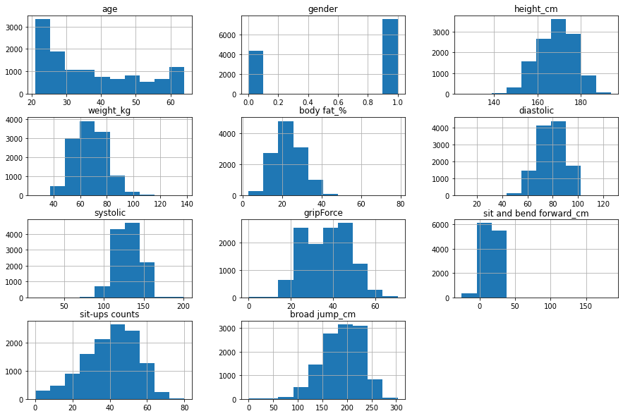

```python
df[numeric].hist(figsize=(15,10));
```

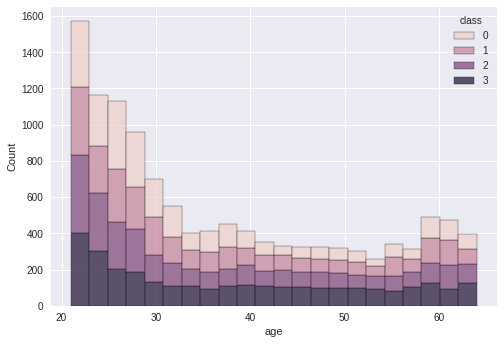

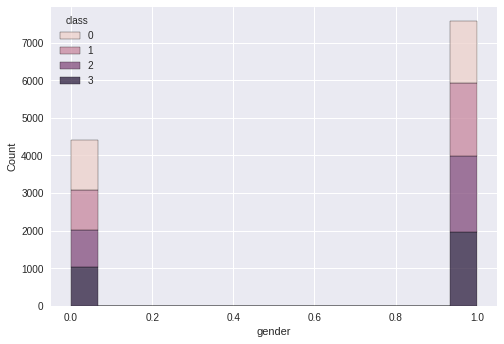

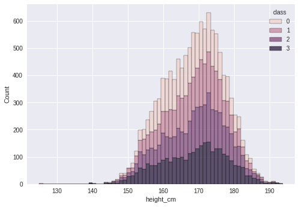

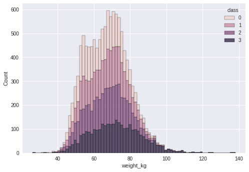

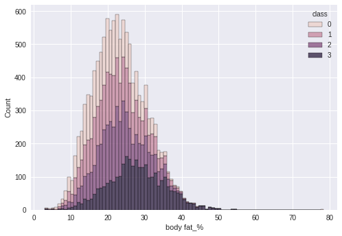

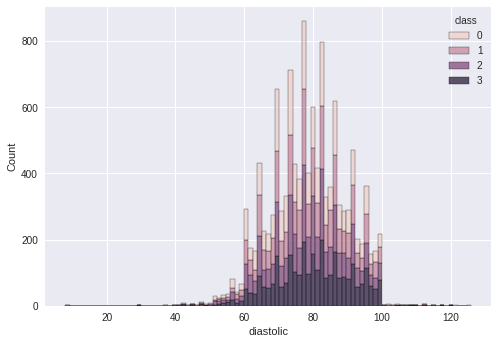

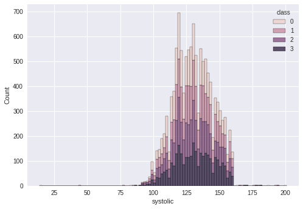

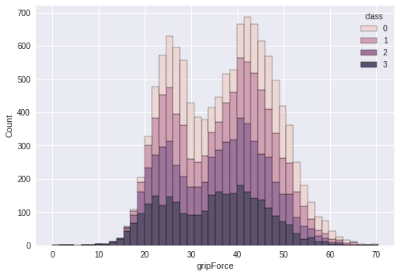

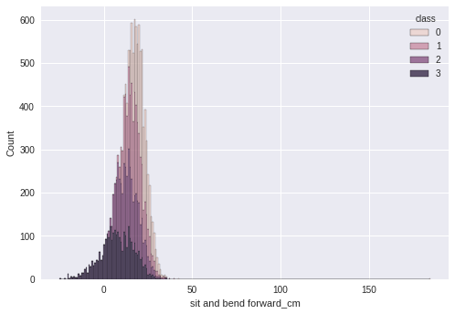

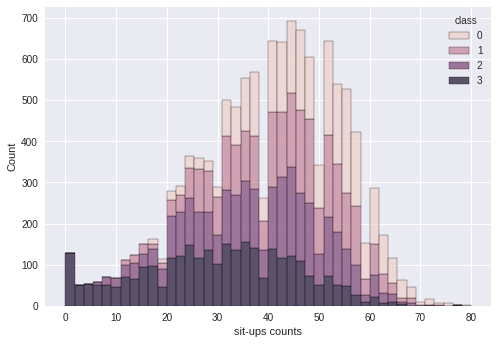

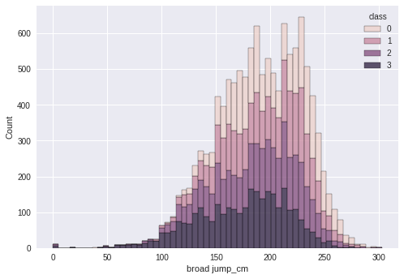

```python
plt.style.use('seaborn')
for i in numeric:
  sns.histplot(data= df, x= i, hue= 'class', multiple= 'stack')
  plt.show()
```

[figure not shown]

```python
sns.pairplot(df, hue = 'class',size = 2)
```

```python
corr = df[numeric].corr()
corr
```

[output not shown]

[figure not shown]

```python
mask = np.zeros_like(corr, dtype=np.bool)
mask[np.triu_indices_from(mask)] = True

f, ax = plt.subplots(figsize=(6, 4))
sns.heatmap(corr, mask=mask, vmax=1, center=0, annot=True, fmt='.1f',
            square=True, linewidths=.5, cbar_kws={"shrink": .5});
```

# Build a preliminar model

En aquest apartat he fet proves de varis algorismes:

- DecisionTreeClassifier
- AdaBoostClassifier
- BaggingClassifier
- RandomForestClassifier
- XGBClassifier

He aconseguit més accuracy amb força diferencia amb *XGBClassifier*.

Defineixo una funció per fer proves amb **XGBClassifier** i faig una primera prova:

```python
target='class'
predictors = [x for x in df.columns if x not in [target]]
```

```python
def classifier(data,target_column):
  from sklearn.model_selection import train_test_split
  from xgboost import XGBClassifier
  from sklearn.metrics import accuracy_score
  from sklearn.metrics import confusion_matrix
  from datetime import datetime
  from matplotlib import pyplot as plt
  import numpy as np
  from mlxtend.plotting import plot_confusion_matrix

  # TRAIN TEST SPLIT 1(example without timeseries)
  data_numeric = data.select_dtypes(include=["number"])# Force only numeric columns
  X = data_numeric.drop(target_column, axis = 1)
  y = data_numeric[target_column]
  X_train, X_test, y_train, y_test = train_test_split(X, y, test_size = .3,random_state = 5,stratify=y)


  # XGBOOST
  model = XGBClassifier()
  model.fit(X_train, y_train)

  # TEST EVALUATION
  y_pred = model.predict(X_test)
  print("Accuracy: %.2f%%" % (accuracy_score(y_test, y_pred)*100))

  # SAVE TEST RESULTS
  result = pd.concat([X_test, pd.DataFrame({"predicted":y_pred,target_column:y_test})], axis = 'columns')
  result['error'] = result['predicted']-result[target_column]
  result['error_abs'] = abs(result['predicted']-result[target_column])
  result.to_csv("test_result.csv",index=None,decimal=",",sep=";")

  # PLOT FEATURE IMPORTANCES
  result = {}
  for i, feature in enumerate(X.columns):
      result[feature] = model.feature_importances_[i]
  f_importances = sorted(result.items(), key=lambda x: x[1], reverse=True)

  feat_names =[a_tuple[0] for a_tuple in f_importances]
  score = [a_tuple[1] for a_tuple in f_importances]

  fig, ax = plt.subplots(figsize=(6, 6))
  ax.barh(np.arange(len(f_importances)), score, left=0.001)
  ax.set_yticks(np.arange(len(f_importances)))
  ax.set_yticklabels(feat_names)
  ax.invert_yaxis()  # feat read top-to-bottom
  ax.set_xlabel('Score')
  ax.set_ylabel('Feature')
  ax.set_title('Features importances')
  plt.show()

  df_feat_importances = pd.DataFrame()
  df_feat_importances['feature'] = feat_names
  df_feat_importances['score'] = score
  print(df_feat_importances)

  # PLOT CONFUSION MATRIX
  fig, ax = plot_confusion_matrix(conf_mat=confusion_matrix(y_test, y_pred))
  plt.xlabel('Predictions')
  plt.ylabel('Real')
  plt.title('Confusion Matrix')
  plt.show()
```

```
Accuracy: 68.56%
```

[figure not shown]

[output not shown]

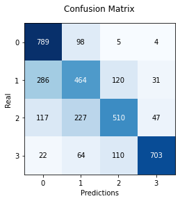

```python
classifier(df,'class')
```

Instanciem un classificador i inicialitzem paràmetres amb un **learning rate inicial de 0.1**.

```python
xgb1 = XGBClassifier(
 learning_rate =0.1,
 n_estimators=1000,
 max_depth=5,
 min_child_weight=1,
 gamma=0,
 subsample=0.8,
 colsample_bytree=0.8,
 objective= 'multi:softprob',
 num_class=4,
 nthread=4,
 scale_pos_weight=1,
 seed=27)
```

Fem un primer entrenament afegint estimadors fins al punt on **afegir 50 estimadors no disminueix l'error**.

```python
xgb_param=xgb1.get_xgb_params()
xgtrain = xgb.DMatrix(df[predictors].values, label=df[target].values)
cvresult = xgb.cv(xgb_param, xgtrain, num_boost_round=xgb1.get_params()['n_estimators'], nfold=5, early_stopping_rounds=50)
```

```python
cvresult.shape[0]#numero optim d'estimadors per learning rate 0.1
```

```
295
```

295 estimadors.

```python
xgb1.set_params(n_estimators=cvresult.shape[0])
xgb1.fit(df[predictors], df['class'])
```

[output not shown]

```python
df_predictions = xgb1.predict(df[predictors])
```

```python
print ("Accuracy : %.4g" % metrics.accuracy_score(df['class'].values, df_predictions))
```

```
Accuracy : 0.8648
```

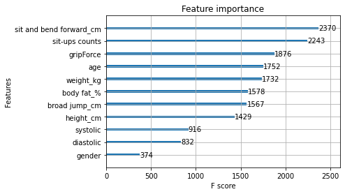

```python
plot_importance(xgb1)
plt.show()
```

# Preliminar hiperparameter tunning

```python
X=df.iloc[:, :-1]
y=df['class']
```

```python
X_train, X_test, y_train, y_test = train_test_split(X, y, test_size = .3,shuffle=True, stratify=y)
```

Comencem amb l'ajust d'hiperparàmetres, els primers a ajustar són *max_depth*, *min_child_weight*. Utilitzant Grid Search

```python
param_test1 = {
 'max_depth':range(3,10,2),
 'min_child_weight':range(1,6,2)
}
gsearch1 = GridSearchCV(estimator = XGBClassifier( learning_rate =0.1,
 n_estimators=295,
 max_depth=5,
 min_child_weight=1,
 gamma=0,
 subsample=0.8,
 colsample_bytree=0.8,
 objective= 'multi:softmax',
 num_class=4,
 nthread=4),
 param_grid = param_test1,n_jobs=4, cv=4)
```

```python
gsearch1.fit(X_train,y_train)
```

```python
print(gsearch1.best_params_)#max_depth:7 i min_child_weight:1
```

```
{'max_depth': 7, 'min_child_weight': 1}
```

```python
best1=gsearch1.best_estimator_
```

```python
print ("Accuracy : %.4g" % metrics.accuracy_score(y_train, best1.predict(X_train)))#acc training set
print ("Accuracy : %.4g" % metrics.accuracy_score(y_test, best1.predict(X_test)))#acc test set
```

```
Accuracy : 0.9057
Accuracy : 0.7228
```

# Tractament d'outliers

En aquest apartat tractarem outliers, tornarem a ajustar *max_depth* i *min_child_weight* via *GridSearch* i mesurarem la performance dels diferents models.

```python
def outlier_detector(datacolumn):
    sorted(datacolumn)
    Q1,Q3 = np.percentile(datacolumn,[25,75])
    IQR = Q3 - Q1
    lower_bound = Q1-(1.5*IQR)
    upper_bound = Q3+(1.5*IQR)
    return lower_bound,upper_bound
```

```python
index=[]
for i in predictors:
  lowerbound, upperbound = outlier_detector(df[i])
  index.append(df.index[(df[i]>upperbound)|(df[i]<lowerbound)].to_list())
flat_index = [item for sublist in index for item in sublist]
print("Número d'outliers:",len(set(flat_index)))
```

```
Número d'outliers: 590
```

Tenim **590 outliers** utilitzarem 3 criteris de tractament:

- Eliminar-los
- Substituïr-los per la mitjana
- Substituïr-los per el *threshold* de 1.5 vegades la distància interquartil.

Intent 1: Eliminació d'outliers

```python
no_outliers=df.drop(flat_index, axis=0)
no_outliers.reset_index(inplace=True)
no_outliers.drop('index',inplace=True,axis=1)
print(no_outliers.info())
```

```
<class 'pandas.core.frame.DataFrame'>
RangeIndex: 11398 entries, 0 to 11397
Data columns (total 12 columns):
 #   Column                   Non-Null Count  Dtype
---  ------                   --------------  -----
 0   age                      11398 non-null  float64
 1   gender                   11398 non-null  int64
 2   height_cm                11398 non-null  float64
 3   weight_kg                11398 non-null  float64
 4   body fat_%               11398 non-null  float64
 5   diastolic                11398 non-null  float64
 6   systolic                 11398 non-null  float64
 7   gripForce                11398 non-null  float64
 8   sit and bend forward_cm  11398 non-null  float64
 9   sit-ups counts           11398 non-null  float64
 10  broad jump_cm            11398 non-null  float64
 11  class                    11398 non-null  int64
dtypes: float64(10), int64(2)
memory usage: 1.0 MB
None
```

```python
X_out=no_outliers.iloc[:, :-1]
y_out=no_outliers['class']
```

```python
X_outtrain, X_outtest, y_outtrain, y_outtest = train_test_split(X_out, y_out, test_size = .3)
```

```python
print(X_outtrain.shape)
print(X_outtest.shape)
```

```
(7978, 11)
(3420, 11)
```

```python
param_test2 = {
 'max_depth':range(3,10,2),
 'min_child_weight':range(1,6,2)
}
gsearch2 = GridSearchCV(estimator = XGBClassifier( learning_rate =0.1,
 n_estimators=295,
 max_depth=5,
 min_child_weight=1,
 gamma=0,
 subsample=0.8,
 colsample_bytree=0.8,
 objective= 'multi:softprob',
 num_class=4,
 nthread=4),
 param_grid = param_test2,n_jobs=4, cv=4)
```

```python
start=time()

gsearch2.fit(X_outtrain,y_outtrain)
elapsed= time() -start

print(elapsed)
```

```
1233.1338543891907
```

```python
print(gsearch2.best_params_)#max_depth:7 i min_child_weight:2
```

[output not shown]

```python
best2=gsearch2.best_estimator_
```

```python
print ("Accuracy : %.4g" % metrics.accuracy_score(y_outtrain, best2.predict(X_outtrain)))#acc training set
print ("Accuracy : %.4g" % metrics.accuracy_score(y_outtest, best2.predict(X_outtest)))#acc test set 73.2%
```

```
Accuracy : 0.9976
Accuracy : 0.7327
```

```python
out_mean=df.copy()
```

```python
for i in predictors:
    lowerbound, upperbound = outlier_detector(out_mean[i])
    mean = out_mean[i].median()
    out_mean.loc[((out_mean[i] > upperbound)|(out_mean[i] < lowerbound)), i] = mean
```

```python
X_mean=out_mean.iloc[:, :-1]
y_mean=out_mean['class']
```

```python
X_meantrain, X_meantest, y_meantrain, y_meantest = train_test_split(X_mean, y_mean, test_size = .25)#,shuffle=True,stratify=y_out
```

```python
param_test3 = {
 'max_depth':range(3,10,2),
 'min_child_weight':range(1,6,2)
}
gsearch3 = GridSearchCV(estimator = XGBClassifier( learning_rate =0.1,
 n_estimators=295,
 max_depth=5,
 min_child_weight=1,
 gamma=0,
 subsample=0.8,
 colsample_bytree=0.8,
 objective= 'multi:softprob',
 num_class=4,
 nthread=4,
 scale_pos_weight=1,
 seed=27),
 param_grid = param_test3,n_jobs=4, cv=4)
```

```python
start=time()

gsearch3.fit(X_meantrain,y_meantrain)
elapsed= time() -start

print(elapsed)
```

```
1231.5597794055939
```

```python
print(gsearch3.best_params_)
```

[output not shown]

```python
best3=gsearch3.best_estimator_
```

```python
xgb1.fit(X_meantrain,y_meantrain)
```

[output not shown]

```python
print ("Accuracy : %.4g" % metrics.accuracy_score(y_meantrain, xgb1.predict(X_meantrain)))#acc training set
print ("Accuracy : %.4g" % metrics.accuracy_score(y_meantest, xgb1.predict(X_meantest)))#acc test set
```

```
Accuracy : 0.8117
Accuracy : 0.7437
```

Intent 3: Reemplaçar outliers per 1.5 vegades la distància interquartil

```python
out_iqr=df.copy()
```

```python
for i in predictors:
    lowerbound, upperbound = outlier_detector(out_iqr[i])
    out_iqr.loc[(out_iqr[i] > upperbound), i] = upperbound
    out_iqr.loc[(out_iqr[i] < lowerbound), i] = lowerbound
```

```python
X_iqr=out_iqr.iloc[:,:-1]
y_iqr=out_iqr['class']
```

```python
X_iqrtrain, X_iqrtest, y_iqrtrain, y_iqrtest = train_test_split(X_iqr, y_iqr, test_size = .25,shuffle=True,stratify=y_iqr)
```

```python
param_test4 = {
 'max_depth':range(3,10,2),
 'min_child_weight':range(1,6,2)
}
gsearch4 = GridSearchCV(estimator = XGBClassifier( learning_rate =0.1,
 n_estimators=295,
 max_depth=5,
 min_child_weight=1,
 gamma=0,
 subsample=0.8,
 colsample_bytree=0.8,
 objective= 'multi:softprob',
 num_class=4,
 nthread=4,
 scale_pos_weight=1,
 seed=27),
 param_grid = param_test4 ,n_jobs=4, cv=4)
```

```python
start=time()

gsearch4.fit(X_iqrtrain,y_iqrtrain)
elapsed= time() -start

print(elapsed)
```

```
377.00160121917725
```

```python
print(gsearch4.best_params_)
```

```
{'max_depth': 9, 'min_child_weight': 1}
```

```python
best4=gsearch4.best_estimator_
```

```python
best4=XGBClassifier( learning_rate =0.1,
 n_estimators=184,
 max_depth=6,
 min_child_weight=3,
 gamma=0,
 subsample=0.8,
 colsample_bytree=0.8,
 objective= 'multi:softprob',
 num_class=4,
 nthread=4,
 scale_pos_weight=1,
 seed=27)
best4.fit(X_iqrtrain,y_iqrtrain)
```

```python
xgb1.fit(X_iqrtrain,y_iqrtrain)
```

[output not shown]

```python
print ("Accuracy : %.4g" % metrics.accuracy_score(y_iqrtrain, xgb1.predict(X_iqrtrain)))#acc training set
print ("Accuracy : %.4g" % metrics.accuracy_score(y_iqrtest, xgb1.predict(X_iqrtest)))#acc test set
```

```
Accuracy : 0.8133
Accuracy : 0.7541
```

[figure not shown]

```python
xgb.plot_importance(best4)
```

# Hiperparameter tunning

En aquest apartat he ajustat els hiperparàmetres mitjançant un procés iteratiu i evaluant la performance en els diferents conjunts:

- X_outtrain, X_outtest, y_outtrain, y_outtest (outliers eliminats)
- X_meantrain, X_meantest, y_meantrain, y_meantest (outliers substituits per la mitjana)
- X_iqrtrain, X_iqrtest, y_iqrtrain, y_iqrtest (outliers substituits 1.5IQR)
- X_train, X_test, y_train, y_test (no tractats)

*Gamma*, desprès d'iterar per varis valors l'ajustem a 4.6:

```python
gamma=[4.59,4.6,4.61]
```

```python
for i in gamma:
  print('gamma ',i)
  estimator = XGBClassifier( learning_rate =0.1,
  n_estimators=295,
  max_depth=7,
  min_child_weight=1,
  gamma=i,
  subsample=0.8,
  colsample_bytree=0.8,
  objective= 'multi:softprob',
  num_class=4,
  nthread=4)
  a=estimator.fit(X_iqrtrain,y_iqrtrain,eval_metric='auc')
  print('Results IQR')
  print ("Accuracy : %.4g" % metrics.accuracy_score(y_iqrtrain, a.predict(X_iqrtrain)))#acc training set
  print ("Accuracy : %.4g" % metrics.accuracy_score(y_iqrtest, a.predict(X_iqrtest)))#acc test set
  print('Results MEAN')
  b=estimator.fit(X_meantrain,y_meantrain,eval_metric='auc')
  print ("Accuracy : %.4g" % metrics.accuracy_score(y_meantrain, b.predict(X_meantrain)))#acc training set
  print ("Accuracy : %.4g" % metrics.accuracy_score(y_meantest, b.predict(X_meantest)))#acc test set
  print('Results WITHOUT OUTLIERS')
  c=estimator.fit(X_outtrain,y_outtrain,eval_metric='auc')
  print ("Accuracy : %.4g" % metrics.accuracy_score(y_outtrain, b.predict(X_outtrain)))#acc training set
  print ("Accuracy : %.4g" % metrics.accuracy_score(y_outtest, b.predict(X_outtest)))#acc test set
  print('Results NOTHING')
  d=estimator.fit(X_train,y_train,eval_metric='auc')
  print ("Accuracy : %.4g" % metrics.accuracy_score(y_train, b.predict(X_train)))#acc training set
  print ("Accuracy : %.4g" % metrics.accuracy_score(y_test, b.predict(X_test)))#acc test set
```

```
gamma  4.59
Results IQR
Accuracy : 0.8205
Accuracy : 0.7591
Results MEAN
Accuracy : 0.8208
Accuracy : 0.7331
Results WITHOUT OUTLIERS
Accuracy : 0.8174
Accuracy : 0.7436
Results NOTHING
Accuracy : 0.816
Accuracy : 0.7428
gamma  4.6
Results IQR
Accuracy : 0.8215
Accuracy : 0.7611
Results MEAN
Accuracy : 0.8199
Accuracy : 0.7327
Results WITHOUT OUTLIERS
Accuracy : 0.8134
Accuracy : 0.7409
Results NOTHING
Accuracy : 0.8193
Accuracy : 0.7437
gamma  4.61
Results IQR
Accuracy : 0.8209
Accuracy : 0.7574
Results MEAN
Accuracy : 0.821
Accuracy : 0.7321
Results WITHOUT OUTLIERS
Accuracy : 0.8141
Accuracy : 0.7433
Results NOTHING
Accuracy : 0.8178
Accuracy : 0.7434
```

Clarament substituir outliers pels límits té el millors resultats.

*Subsample* i *Colsample_bytree*:

```python
subsample=[0.6, 0.7, 0.8, 0.9, 1]
colsample_bytree=[0.6, 0.7, 0.8, 0.9, 1]
```

```python
for i in subsample:
  print('subsample ',i)
  for j in colsample_bytree:
    print('colsample_bytree ',j)
    estimator = XGBClassifier( learning_rate =0.1,
    n_estimators=295,
    max_depth=7,
    min_child_weight=1,
    gamma=4.6,
    subsample=i,
    colsample_bytree=j,
    objective= 'multi:softprob',
    num_class=4,
    nthread=4)
    a=estimator.fit(X_iqrtrain,y_iqrtrain,eval_metric='auc')
    print('Results IQR')
    print ("Accuracy : %.4g" % metrics.accuracy_score(y_iqrtrain, a.predict(X_iqrtrain)))#acc training set
    print ("Accuracy : %.4g" % metrics.accuracy_score(y_iqrtest, a.predict(X_iqrtest)))#acc test set
```

```
subsample  0.6
colsample_bytree  0.6
Results IQR
Accuracy : 0.8068
Accuracy : 0.7574
colsample_bytree  0.7
Results IQR
Accuracy : 0.8098
Accuracy : 0.7521
colsample_bytree  0.8
Results IQR
Accuracy : 0.8134
Accuracy : 0.7504
colsample_bytree  0.9
Results IQR
Accuracy : 0.8153
Accuracy : 0.7571
subsample  0.7
colsample_bytree  0.6
Results IQR
Accuracy : 0.8125
Accuracy : 0.7614
colsample_bytree  0.7
Results IQR
Accuracy : 0.8127
Accuracy : 0.7554
colsample_bytree  0.8
Results IQR
Accuracy : 0.8174
Accuracy : 0.7631
colsample_bytree  0.9
Results IQR
Accuracy : 0.8194
Accuracy : 0.7608
subsample  0.8
colsample_bytree  0.6
Results IQR
Accuracy : 0.817
Accuracy : 0.7631
colsample_bytree  0.7
```

[output cut: 13 more lines]

```
Results IQR
Accuracy : 0.8174
Accuracy : 0.7631
colsample_bytree  0.7
Results IQR
Accuracy : 0.819
Accuracy : 0.7628
colsample_bytree  0.8
Results IQR
Accuracy : 0.8232
Accuracy : 0.7668
colsample_bytree  0.9
Results IQR
Accuracy : 0.8246
Accuracy : 0.7654
```

*Reg_alpha*, després de varies iteracions:

```python
reg_alpha=[0.88,0.89, 0.9]
```

```python
for i in reg_alpha:
  print('reg_alpha ',i)
  estimator = XGBClassifier( learning_rate =0.1,
  n_estimators=295,
  max_depth=7,
  min_child_weight=1,
  gamma=4.6,
  subsample=0.9,
  colsample_bytree=0.8,
  objective= 'multi:softprob',
  num_class=4,
  reg_alpha=i,
  nthread=4)
  a=estimator.fit(X_iqrtrain,y_iqrtrain,eval_metric='auc')
  print('Results IQR')
  print ("Accuracy : %.4g" % metrics.accuracy_score(y_iqrtrain, a.predict(X_iqrtrain)))#acc training set
  print ("Accuracy : %.4g" % metrics.accuracy_score(y_iqrtest, a.predict(X_iqrtest)))#acc test set
```

```
reg_alpha  0.88
Results IQR
Accuracy : 0.8108
Accuracy : 0.7664
reg_alpha  0.89
Results IQR
Accuracy : 0.8116
Accuracy : 0.7671
reg_alpha  0.9
Results IQR
Accuracy : 0.812
Accuracy : 0.7674
```

# Hiperparàmeter tunning: Segona iteració

En aquest apartat he disminuït el **learning_rate** i recalculat el **número d'estimadors**, he tornat a ajustar tots els hiperparàmetres utilitzant *GridSearch* i finalment, he extret conclusions dels resultats.

```python
xgb10 = XGBClassifier( learning_rate =0.05,
n_estimators=5000,
max_depth=7,
min_child_weight=1,
gamma=4.6,
subsample=0.9,
colsample_bytree=0.8,
objective= 'multi:softprob',
num_class=4,
reg_alpha=0.9,
nthread=4)
```

```python
xgb_param=xgb10.get_xgb_params()
xgtrain = xgb.DMatrix(out_iqr[predictors].values, label=out_iqr[target].values)
cvresult = xgb.cv(xgb_param, xgtrain, num_boost_round=xgb10.get_params()['n_estimators'], nfold=10, early_stopping_rounds=50)
```

```python
cvresult.shape[0]#numero optim d'estimadors
```

```
576
```

```python
newmodel = XGBClassifier( learning_rate=0.05,
n_estimators=576,
max_depth=7,
min_child_weight=1,
gamma=4.6,
subsample=1,
colsample_bytree=0.9,
objective= 'multi:softprob',
num_class=4,
reg_alpha=0.9,
nthread=4)
```

```python
z=newmodel.fit(X_iqrtrain,y_iqrtrain)#outliers boundaries tractats
print('Results IQR')
print ("Accuracy : %.4g" % metrics.accuracy_score(y_iqrtrain, z.predict(X_iqrtrain)))#acc training set
print ("Accuracy : %.4g" % metrics.accuracy_score(y_iqrtest, z.predict(X_iqrtest)))#acc test set
```

```
Results IQR
Accuracy : 0.8138
Accuracy : 0.7578
```

```python
cross_val_score(newmodel,out_iqr[predictors],out_iqr[target],cv=5)
```

```
array([0.76605505, 0.74228524, 0.74478732, 0.74926992, 0.76095119])
```

```python
param_test1 = {
 'max_depth':range(3,10,1),
 'min_child_weight':range(1,6,1)
}
gsearch1 = GridSearchCV(estimator = XGBClassifier( learning_rate=0.05,
n_estimators=576,
max_depth=7,
min_child_weight=1,
gamma=4.6,
subsample=1,
colsample_bytree=0.9,
objective= 'multi:softprob',
num_class=4,
reg_alpha=0.9,
nthread=4),
param_grid = param_test1,n_jobs=4, cv=4)
```

```python
start=time()

gsearch1.fit(X_iqrtrain,y_iqrtrain)
elapsed= time() -start

print(elapsed)
```

```
2163.3139238357544
```

```python
print(gsearch1.best_params_)
best1=gsearch1.best_estimator_
```

```
{'max_depth': 9, 'min_child_weight': 3}
```

```python
print ("Accuracy : %.4g" % metrics.accuracy_score(y_iqrtrain, best1.predict(X_iqrtrain)))#acc training set
print ("Accuracy : %.4g" % metrics.accuracy_score(y_iqrtest, best1.predict(X_iqrtest)))#acc test set
```

```
Accuracy : 0.8186
Accuracy : 0.7521
```

```python
param_test2 = {
'gamma':[4.59,4.6,4.61]
}
gsearch2 = GridSearchCV(estimator = XGBClassifier(learning_rate=0.05,
n_estimators=576,
max_depth=9,
min_child_weight=3,
gamma=4.6,
subsample=1,
colsample_bytree=0.9,
objective= 'multi:softprob',
num_class=4,
reg_alpha=0.9,
nthread=4),
param_grid = param_test2,n_jobs=4, cv=4)
```

```python
start=time()

gsearch2.fit(X_iqrtrain,y_iqrtrain)
elapsed= time() -start

print(elapsed)
```

```
352.0292639732361
```

```python
print(gsearch2.best_params_)
best2=gsearch2.best_estimator_
```

```
{'gamma': 4.6}
```

```python
print ("Accuracy : %.4g" % metrics.accuracy_score(y_iqrtrain, best2.predict(X_iqrtrain)))#acc training set
print ("Accuracy : %.4g" % metrics.accuracy_score(y_iqrtest, best2.predict(X_iqrtest)))#acc test set
```

```
Accuracy : 0.8186
Accuracy : 0.7521
```

```python
subsample=[0.6, 0.7, 0.8, 0.9, 1]
colsample_bytree=[0.6, 0.7, 0.8, 0.9, 1]
```

```python
for i in subsample:
  print('subsample ',i)
  for j in colsample_bytree:
    print('colsample_bytree ',j)
    estimator = XGBClassifier(learning_rate=0.05,
n_estimators=576,
max_depth=9,
min_child_weight=3,
gamma=4.6,
subsample=i,
colsample_bytree=j,
objective= 'multi:softprob',
num_class=4,
reg_alpha=0.9,
nthread=4)
    a=estimator.fit(X_iqrtrain,y_iqrtrain,eval_metric='auc')
    print('Results IQR')
    print ("Accuracy : %.4g" % metrics.accuracy_score(y_iqrtrain, a.predict(X_iqrtrain)))#acc training set
    print ("Accuracy : %.4g" % metrics.accuracy_score(y_iqrtest, a.predict(X_iqrtest)))#acc test set
```

```
subsample  0.6
colsample_bytree  0.6
Results IQR
Accuracy : 0.8027
Accuracy : 0.7501
colsample_bytree  0.7
Results IQR
Accuracy : 0.8058
Accuracy : 0.7494
colsample_bytree  0.8
Results IQR
Accuracy : 0.8076
Accuracy : 0.7477
colsample_bytree  0.9
Results IQR
Accuracy : 0.8096
Accuracy : 0.7474
colsample_bytree  1
Results IQR
Accuracy : 0.8145
Accuracy : 0.7511
subsample  0.7
colsample_bytree  0.6
Results IQR
Accuracy : 0.8111
Accuracy : 0.7524
colsample_bytree  0.7
Results IQR
Accuracy : 0.8134
Accuracy : 0.7544
colsample_bytree  0.8
Results IQR
Accuracy : 0.8167
Accuracy : 0.7548
colsample_bytree  0.9
Results IQR
Accuracy : 0.8178
Accuracy : 0.7544
colsample_bytree  1
Results IQR
```

[output cut: 50 more lines]

```
Results IQR
Accuracy : 0.8212
Accuracy : 0.7574
colsample_bytree  0.8
Results IQR
Accuracy : 0.8195
Accuracy : 0.7571
colsample_bytree  0.9
Results IQR
Accuracy : 0.8186
Accuracy : 0.7521
colsample_bytree  1
Results IQR
Accuracy : 0.8096
Accuracy : 0.7487
```

[figure not shown]

```python
xgb.plot_importance(a)
```

```python
param_test3 = {
 'reg_alpha':[1e-5, 1e-2, 0.1, 0.88,0.89, 0.9,1,5]
}
gsearch3 = GridSearchCV(estimator = XGBClassifier(learning_rate=0.05,
n_estimators=576,
max_depth=9,
min_child_weight=3,
gamma=4.6,
subsample=0.9,
colsample_bytree=0.6,
objective= 'multi:softprob',
num_class=4,
reg_alpha=0.9,
nthread=4),
param_grid = param_test3,n_jobs=4, cv=4)
```

```python
start=time()

gsearch3.fit(X_iqrtrain,y_iqrtrain)
elapsed= time() -start

print(elapsed)
```

```
725.1000926494598
```

```python
print(gsearch3.best_params_)
best3=gsearch3.best_estimator_
```

```
{'reg_alpha': 0.1}
```

```python
print ("Accuracy : %.4g" % metrics.accuracy_score(y_iqrtrain, best3.predict(X_iqrtrain)))#acc training set
print ("Accuracy : %.4g" % metrics.accuracy_score(y_iqrtest, best3.predict(X_iqrtest)))#acc test set
```

```
Accuracy : 0.8299
Accuracy : 0.7581
```

[figure not shown]

```python
xgb.plot_importance(estimator)
```

```python
estimator = XGBClassifier(learning_rate=0.05,
n_estimators=576,
max_depth=9,
min_child_weight=3,
gamma=4.6,
subsample=0.9,
colsample_bytree=0.6,
objective= 'multi:softprob',
num_class=4,
reg_alpha=0.1,
nthread=4)
```

```python
X_iqrtrain, X_iqrtest, y_iqrtrain, y_iqrtest = train_test_split(X_iqr, y_iqr, test_size = .25,shuffle=True,stratify=y_iqr)
estimator.fit(X_iqrtrain,y_iqrtrain)
```

```
XGBClassifier(colsample_bytree=0.6, gamma=4.6, learning_rate=0.05, max_depth=9,
              min_child_weight=3, n_estimators=576, nthread=4, num_class=4,
              objective='multi:softprob', reg_alpha=0.1, subsample=0.9)
```

```python
print ("Accuracy : %.4g" % metrics.accuracy_score(y_iqrtrain, estimator.predict(X_iqrtrain)))#acc training set
print ("Accuracy : %.4g" % metrics.accuracy_score(y_iqrtest, estimator.predict(X_iqrtest)))#acc test set
```

```
Accuracy : 0.827
Accuracy : 0.7581
```

En aquest cas disminuïr el learning rate **NO MILLORA** resultats.

# Downsampling

En aquest apartat he estat fent experiments en subconjunts estratificats del *train.csv* amb l'objectiu de millorar l'accuracy del model. Primer he realitzat proves amb diversos downsamples del conjunt original, entrenant el model amb els hiperparàmetres ajustats en l'apartat anterior.

```python
n_samples=2988
```

```python
df = df.sample(frac=1).reset_index(drop=True)
```

```python
df.dtypes
```

```
age                        float64
gender                       int64
height_cm                  float64
weight_kg                  float64
body fat_%                 float64
diastolic                  float64
systolic                   float64
gripForce                  float64
sit and bend forward_cm    float64
sit-ups counts             float64
broad jump_cm              float64
class                        int64
dtype: object
```

```python
df_0=df[df['class']==0]
df_1=df[df['class']==1]
df_2=df[df['class']==2]
df_3=df[df['class']==3]
```

```python
df_0_down=resample(df_0,replace=False,n_samples=n_samples,random_state=42)
df_1_down=resample(df_1,replace=False,n_samples=n_samples,random_state=42)
df_2_down=resample(df_2,replace=False,n_samples=n_samples,random_state=42)
df_3_down=resample(df_3,replace=False,n_samples=n_samples,random_state=42)
```

```python
df_down=pd.concat([df_0_down,df_1_down,df_2_down,df_3_down])
```

```python
xgb1 = XGBClassifier( learning_rate =0.1,
  n_estimators=1000,
  max_depth=7,
  min_child_weight=1,
  gamma=4.6,
  subsample=0.9,
  colsample_bytree=0.8,
  objective= 'multi:softprob',
  num_class=4,
  reg_alpha=0.9,
  nthread=4)
```

```python
xgb_param=xgb1.get_xgb_params()
xgtrain = xgb.DMatrix(df_down[predictors].values, label=df_down[target].values)
cvresult = xgb.cv(xgb_param, xgtrain, num_boost_round=xgb1.get_params()['n_estimators'], nfold=10, early_stopping_rounds=50)
```

```python
cvresult.shape[0]#numero optim d'estimadors per learning rate 0.1
```

```
295
```

[figure not shown]

```python
plot_importance(xgb1)
plt.show()
```

```python
X=df_down[predictors]
y=df_down['class']
```

```python
X_train, X_test, y_train, y_test = train_test_split(X, y, test_size = .25,shuffle=True, stratify=y)
```

```python
xgb1.fit(X_train,y_train)
print ("Accuracy : %.4g" % metrics.accuracy_score(y_train, xgb1.predict(X_train)))#acc training set
print ("Accuracy : %.4g" % metrics.accuracy_score(y_test, xgb1.predict(X_test)))#acc test set
```

```
Accuracy : 0.8128
Accuracy : 0.7557
```

Seguidament he fet el mateix tractant previament outliers, subtituint-los pels limits:

```python
out_iqr=df_down.copy()
```

```python
for i in list(out_iqr.columns)[:-1]:
    lowerbound, upperbound = outlier_detector(out_iqr[i])
    out_iqr.loc[(out_iqr[i] > upperbound), i] = upperbound
    out_iqr.loc[(out_iqr[i] < lowerbound), i] = lowerbound
```

```python
X_iqr=out_iqr[(out_iqr.columns)[:-1]]
y_iqr=out_iqr['class']
X_iqrtrain, X_iqrtest, y_iqrtrain, y_iqrtest = train_test_split(X_iqr, y_iqr, test_size = .1,shuffle=True,stratify=y_iqr)
xgb1 = XGBClassifier(
 learning_rate =0.1,
 n_estimators=295,
 max_depth=7,
 min_child_weight=1,
 gamma=4.6,
 subsample=0.9,
 colsample_bytree=0.6,
 objective= 'multi:softprob',
 num_class=4,
 nthread=4,

 reg_alpha=0.9,
 missing=None,
 eval_metric='merror',
 scale_pos_weight=10)
xgb1.fit(X_iqrtrain,y_iqrtrain,verbose=True,eval_set=[(X_iqrtest,y_iqrtest)])
print ("Accuracy : %.4g" % metrics.accuracy_score(y_iqrtrain, xgb1.predict(X_iqrtrain)))#acc training set
print ("Accuracy : %.4g" % metrics.accuracy_score(y_iqrtest, xgb1.predict(X_iqrtest)))#acc test set
print ("F1score(micro) : %.4g" % metrics.f1_score(y_iqrtest, xgb1.predict(X_iqrtest),average='micro'))#acc test set
```

[output not shown]

[figure not shown]

```python
plot_confusion_matrix(xgb1,X_iqrtest,y_iqrtest,values_format='d',display_labels=['A','B','C','D'])
```

```python
print ("Accuracy : %.4g" % metrics.accuracy_score(y_iqrtrain, xgb1.predict(X_iqrtrain)))#acc training set
print ("Accuracy : %.4g" % metrics.accuracy_score(y_iqrtest, xgb1.predict(X_iqrtest)))#acc test set
```

```
Accuracy : 0.808
Accuracy : 0.775
```

Aquest ha estat el model que m'ha donat la màxima **public score**.

# Feature engineering

En aquest apartat he realitzat moltes proves treballant en local (logaritme de age, combinació de columnes, polynomial features, eliminar columnes...). Una técnica concreta m'ha permés arribar al **79% de private score**, lamentablement no tenia prou **public score** i no ha estat seleccionada.

[figure not shown]

La idea que he tingut en ment ha estat simplificar la informació a introduïr al model mantenint una bona accuracy. Per tant he fet servir la següent metodologia: